# Risk Factor Analysis

## Outcome Variable

**Outcome Variable:** whz

## Predictor Variables

**Intervention Variable:** exclfeed36

**Adjustment Set:**

- arm
- sex
- W_mage
- meducyrs
- feducyrs
- hhwealth_quart
- hfoodsec
- W_mhtcm
- vagbrth
- W_gagebrth
- W_birthwt
- W_birthlen
- W_nrooms
- W_nchldlt5
- month
- brthmon
- W_parity
- impfloor
- impsan
- safeh20
- delta_W_mage
- delta_meducyrs
- delta_feducyrs
- delta_hhwealth_quart
- delta_hfoodsec
- delta_W_mhtcm
- delta_vagbrth
- delta_W_gagebrth
- delta_W_birthwt
- delta_W_birthlen
- delta_W_nrooms
- delta_W_nchldlt5
- delta_month
- delta_brthmon
- delta_W_parity
- delta_impfloor
- delta_impsan
- delta_safeh20

## Stratifying Variables

The analysis was stratified on these variable(s):

- agecat
- studyid
- country

## Data Summary

| agecat | studyid | country | exclfeed36 | n_cell | n |
| --- | --- | --- | --- | --- | --- |
| Birth | ki0047075b-MAL-ED | BANGLADESH | 1 | 58 | 230 |
| Birth | ki0047075b-MAL-ED | BANGLADESH | 0 | 172 | 230 |
| Birth | ki0047075b-MAL-ED | BRAZIL | 1 | 12 | 177 |
| Birth | ki0047075b-MAL-ED | BRAZIL | 0 | 165 | 177 |
| Birth | ki0047075b-MAL-ED | INDIA | 1 | 5 | 195 |
| Birth | ki0047075b-MAL-ED | INDIA | 0 | 190 | 195 |
| Birth | ki0047075b-MAL-ED | NEPAL | 1 | 11 | 167 |
| Birth | ki0047075b-MAL-ED | NEPAL | 0 | 156 | 167 |
| Birth | ki0047075b-MAL-ED | PERU | 1 | 15 | 266 |
| Birth | ki0047075b-MAL-ED | PERU | 0 | 251 | 266 |
| Birth | ki0047075b-MAL-ED | SOUTH AFRICA | 1 | 0 | 234 |
| Birth | ki0047075b-MAL-ED | SOUTH AFRICA | 0 | 234 | 234 |
| Birth | ki0047075b-MAL-ED | TANZANIA, UNITED REPUBLIC OF | 1 | 1 | 116 |
| Birth | ki0047075b-MAL-ED | TANZANIA, UNITED REPUBLIC OF | 0 | 115 | 116 |
| Birth | ki1000108-CMC-V-BCS-2002 | INDIA | 1 | 3 | 3 |
| Birth | ki1000108-CMC-V-BCS-2002 | INDIA | 0 | 0 | 3 |
| Birth | ki1000108-IRC | INDIA | 1 | 0 | 3 |
| Birth | ki1000108-IRC | INDIA | 0 | 3 | 3 |
| Birth | ki1000109-EE | PAKISTAN | 1 | 0 | 1 |
| Birth | ki1000109-EE | PAKISTAN | 0 | 1 | 1 |
| Birth | ki1101329-Keneba | GAMBIA | 1 | 345 | 1202 |
| Birth | ki1101329-Keneba | GAMBIA | 0 | 857 | 1202 |
| Birth | kiGH5241-JiVitA-3 | BANGLADESH | 1 | 9175 | 11319 |
| Birth | kiGH5241-JiVitA-3 | BANGLADESH | 0 | 2144 | 11319 |
| Birth | kiGH5241-JiVitA-4 | BANGLADESH | 1 | 491 | 602 |
| Birth | kiGH5241-JiVitA-4 | BANGLADESH | 0 | 111 | 602 |
| 6 months | ki0047075b-MAL-ED | BANGLADESH | 1 | 63 | 240 |
| 6 months | ki0047075b-MAL-ED | BANGLADESH | 0 | 177 | 240 |
| 6 months | ki0047075b-MAL-ED | BRAZIL | 1 | 17 | 209 |
| 6 months | ki0047075b-MAL-ED | BRAZIL | 0 | 192 | 209 |

[output cut: 60 more lines]

The following strata were considered:

- agecat: 24 months, studyid: ki0047075b-MAL-ED, country: BANGLADESH
- agecat: 24 months, studyid: ki0047075b-MAL-ED, country: BRAZIL
- agecat: 24 months, studyid: ki0047075b-MAL-ED, country: INDIA
- agecat: 24 months, studyid: ki0047075b-MAL-ED, country: NEPAL
- agecat: 24 months, studyid: ki0047075b-MAL-ED, country: PERU
- agecat: 24 months, studyid: ki0047075b-MAL-ED, country: SOUTH AFRICA
- agecat: 24 months, studyid: ki0047075b-MAL-ED, country: TANZANIA, UNITED REPUBLIC OF
- agecat: 24 months, studyid: ki1000108-CMC-V-BCS-2002, country: INDIA
- agecat: 24 months, studyid: ki1000108-IRC, country: INDIA
- agecat: 24 months, studyid: ki1017093b-PROVIDE, country: BANGLADESH
- agecat: 24 months, studyid: ki1101329-Keneba, country: GAMBIA
- agecat: 24 months, studyid: ki1113344-GMS-Nepal, country: NEPAL
- agecat: 24 months, studyid: ki1148112-LCNI-5, country: MALAWI
- agecat: 24 months, studyid: kiGH5241-JiVitA-3, country: BANGLADESH
- agecat: 24 months, studyid: kiGH5241-JiVitA-4, country: BANGLADESH
- agecat: 6 months, studyid: ki0047075b-MAL-ED, country: BANGLADESH
- agecat: 6 months, studyid: ki0047075b-MAL-ED, country: BRAZIL
- agecat: 6 months, studyid: ki0047075b-MAL-ED, country: INDIA
- agecat: 6 months, studyid: ki0047075b-MAL-ED, country: NEPAL
- agecat: 6 months, studyid: ki0047075b-MAL-ED, country: PERU
- agecat: 6 months, studyid: ki0047075b-MAL-ED, country: SOUTH AFRICA
- agecat: 6 months, studyid: ki0047075b-MAL-ED, country: TANZANIA, UNITED REPUBLIC OF
- agecat: 6 months, studyid: ki1000108-CMC-V-BCS-2002, country: INDIA
- agecat: 6 months, studyid: ki1000108-IRC, country: INDIA
- agecat: 6 months, studyid: ki1000109-EE, country: PAKISTAN
- agecat: 6 months, studyid: ki1000304b-SAS-FoodSuppl, country: INDIA
- agecat: 6 months, studyid: ki1017093b-PROVIDE, country: BANGLADESH
- agecat: 6 months, studyid: ki1101329-Keneba, country: GAMBIA
- agecat: 6 months, studyid: ki1113344-GMS-Nepal, country: NEPAL
- agecat: 6 months, studyid: ki1148112-LCNI-5, country: MALAWI
- agecat: 6 months, studyid: kiGH5241-JiVitA-3, country: BANGLADESH
- agecat: 6 months, studyid: kiGH5241-JiVitA-4, country: BANGLADESH
- agecat: Birth, studyid: ki0047075b-MAL-ED, country: BANGLADESH
- agecat: Birth, studyid: ki0047075b-MAL-ED, country: BRAZIL
- agecat: Birth, studyid: ki0047075b-MAL-ED, country: INDIA
- agecat: Birth, studyid: ki0047075b-MAL-ED, country: NEPAL
- agecat: Birth, studyid: ki0047075b-MAL-ED, country: PERU
- agecat: Birth, studyid: ki0047075b-MAL-ED, country: SOUTH AFRICA
- agecat: Birth, studyid: ki0047075b-MAL-ED, country: TANZANIA, UNITED REPUBLIC OF
- agecat: Birth, studyid: ki1000108-CMC-V-BCS-2002, country: INDIA
- agecat: Birth, studyid: ki1000108-IRC, country: INDIA
- agecat: Birth, studyid: ki1000109-EE, country: PAKISTAN
- agecat: Birth, studyid: ki1101329-Keneba, country: GAMBIA
- agecat: Birth, studyid: kiGH5241-JiVitA-3, country: BANGLADESH
- agecat: Birth, studyid: kiGH5241-JiVitA-4, country: BANGLADESH

### Dropped Strata

- agecat: Birth, studyid: ki0047075b-MAL-ED, country: SOUTH AFRICA
- agecat: Birth, studyid: ki0047075b-MAL-ED, country: TANZANIA, UNITED REPUBLIC OF
- agecat: Birth, studyid: ki1000108-CMC-V-BCS-2002, country: INDIA
- agecat: Birth, studyid: ki1000108-IRC, country: INDIA
- agecat: Birth, studyid: ki1000109-EE, country: PAKISTAN
- agecat: 6 months, studyid: ki0047075b-MAL-ED, country: SOUTH AFRICA
- agecat: 6 months, studyid: ki0047075b-MAL-ED, country: TANZANIA, UNITED REPUBLIC OF
- agecat: 6 months, studyid: ki1000108-CMC-V-BCS-2002, country: INDIA
- agecat: 6 months, studyid: ki1000108-IRC, country: INDIA
- agecat: 6 months, studyid: ki1000304b-SAS-FoodSuppl, country: INDIA
- agecat: 24 months, studyid: ki0047075b-MAL-ED, country: SOUTH AFRICA
- agecat: 24 months, studyid: ki0047075b-MAL-ED, country: TANZANIA, UNITED REPUBLIC OF
- agecat: 24 months, studyid: ki1000108-CMC-V-BCS-2002, country: INDIA
- agecat: 24 months, studyid: ki1000108-IRC, country: INDIA

## Methods Detail

We’re interested in the causal parameters $E[Y_a]$ for all values of $a \in \mathcal{A}$. These parameters represent the mean outcome if, possibly contrary to fact, we intervened to set all units to have $A=a$. Under the randomization and positivity assumptions, these are identified by the statistical parameters $\psi_a=E_W[E_{Y|A,W}(Y|A=a,W)]$. In addition, we’re interested in the mean of $Y$, $E[Y]$ under no intervention (the observed mean). We will estimate these parameters by using SuperLearner to fit the relevant likelihood factors – $E_{Y|A,W}(Y|A=a,W)$ and $p(A=a|W)$, and then updating our likelihood fit using a joint TMLE.

For unadjusted analyses ($W=\{\}$), initial likelihoods were estimated using Lrnr_glm to estimate the simple $E(Y|A)$ and Lrnr_mean to estimate $p(A)$. For adjusted analyses, a small library containing Lrnr_glmnet, Lrnr_xgboost, and Lrnr_mean was used.

Having estimated these parameters, we will then use the delta method to estimate relative risks and attributable risks relative to a prespecified baseline level of $A$.

# Results Detail

## Results Plots

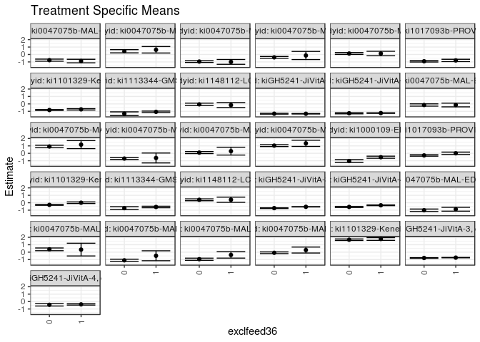

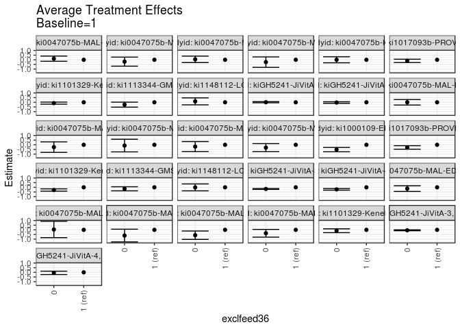

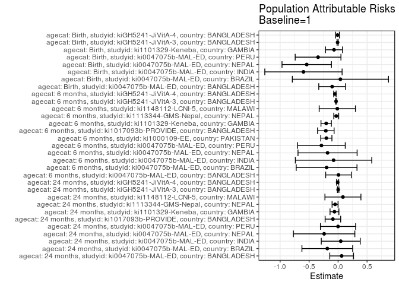

## Results Table

### Parameter: TSM

| agecat | studyid | country | intervention_level | baseline_level | estimate | ci_lower | ci_upper |
| --- | --- | --- | --- | --- | --- | --- | --- |
| Birth | ki0047075b-MAL-ED | BANGLADESH | 1 | NA | -0.8747534 | -1.1333985 | -0.6161083 |
| Birth | ki0047075b-MAL-ED | BANGLADESH | 0 | NA | -1.0134474 | -1.1770179 | -0.8498769 |
| Birth | ki0047075b-MAL-ED | BRAZIL | 1 | NA | 0.3438228 | -0.5137878 | 1.2014334 |
| Birth | ki0047075b-MAL-ED | BRAZIL | 0 | NA | 0.3802174 | 0.1968974 | 0.5635374 |
| Birth | ki0047075b-MAL-ED | INDIA | 1 | NA | -0.4840000 | -1.1529255 | 0.1849255 |
| Birth | ki0047075b-MAL-ED | INDIA | 0 | NA | -1.0973684 | -1.2418489 | -0.9528879 |
| Birth | ki0047075b-MAL-ED | NEPAL | 1 | NA | -0.3716452 | -0.7987240 | 0.0554336 |
| Birth | ki0047075b-MAL-ED | NEPAL | 0 | NA | -0.9484907 | -1.0927066 | -0.8042748 |
| Birth | ki0047075b-MAL-ED | PERU | 1 | NA | 0.2850871 | -0.1133985 | 0.6835727 |
| Birth | ki0047075b-MAL-ED | PERU | 0 | NA | -0.0849814 | -0.2017027 | 0.0317399 |
| Birth | ki1101329-Keneba | GAMBIA | 1 | NA | 1.7716146 | 1.5935725 | 1.9496566 |
| Birth | ki1101329-Keneba | GAMBIA | 0 | NA | 1.6732551 | 1.5714888 | 1.7750214 |
| Birth | kiGH5241-JiVitA-3 | BANGLADESH | 1 | NA | -0.7360677 | -0.7607783 | -0.7113571 |
| Birth | kiGH5241-JiVitA-3 | BANGLADESH | 0 | NA | -0.7840178 | -0.8313753 | -0.7366602 |
| Birth | kiGH5241-JiVitA-4 | BANGLADESH | 1 | NA | -0.3766506 | -0.4706643 | -0.2826369 |
| Birth | kiGH5241-JiVitA-4 | BANGLADESH | 0 | NA | -0.4322083 | -0.5981649 | -0.2662517 |
| 6 months | ki0047075b-MAL-ED | BANGLADESH | 1 | NA | -0.1472232 | -0.3975875 | 0.1031412 |
| 6 months | ki0047075b-MAL-ED | BANGLADESH | 0 | NA | -0.1469828 | -0.3007602 | 0.0067947 |
| 6 months | ki0047075b-MAL-ED | BRAZIL | 1 | NA | 1.1697813 | 0.6326273 | 1.7069353 |
| 6 months | ki0047075b-MAL-ED | BRAZIL | 0 | NA | 0.9212653 | 0.7497807 | 1.0927500 |
| 6 months | ki0047075b-MAL-ED | INDIA | 1 | NA | -0.6254762 | -1.2926685 | 0.0417161 |
| 6 months | ki0047075b-MAL-ED | INDIA | 0 | NA | -0.7057787 | -0.8330997 | -0.5784578 |
| 6 months | ki0047075b-MAL-ED | NEPAL | 1 | NA | 0.2926616 | -0.2338639 | 0.8191871 |
| 6 months | ki0047075b-MAL-ED | NEPAL | 0 | NA | 0.1004229 | -0.0355205 | 0.2363662 |
| 6 months | ki0047075b-MAL-ED | PERU | 1 | NA | 1.3434527 | 0.9289388 | 1.7579665 |
| 6 months | ki0047075b-MAL-ED | PERU | 0 | NA | 1.0391244 | 0.9114637 | 1.1667851 |
| 6 months | ki1000109-EE | PAKISTAN | 1 | NA | -0.5231674 | -0.6630528 | -0.3832819 |
| 6 months | ki1000109-EE | PAKISTAN | 0 | NA | -1.0381161 | -1.2233828 | -0.8528495 |
| 6 months | ki1017093b-PROVIDE | BANGLADESH | 1 | NA | 0.0027679 | -0.1581250 | 0.1636608 |
| 6 months | ki1017093b-PROVIDE | BANGLADESH | 0 | NA | -0.2806530 | -0.3781386 | -0.1831673 |
| 6 months | ki1101329-Keneba | GAMBIA | 1 | NA | 0.0045788 | -0.1026153 | 0.1117730 |
| 6 months | ki1101329-Keneba | GAMBIA | 0 | NA | -0.2841361 | -0.3476945 | -0.2205778 |
| 6 months | ki1113344-GMS-Nepal | NEPAL | 1 | NA | -0.5689401 | -0.6693906 | -0.4684896 |
| 6 months | ki1113344-GMS-Nepal | NEPAL | 0 | NA | -0.7289851 | -0.9220512 | -0.5359190 |
| 6 months | ki1148112-LCNI-5 | MALAWI | 1 | NA | 0.4060541 | 0.0570095 | 0.7550987 |
| 6 months | ki1148112-LCNI-5 | MALAWI | 0 | NA | 0.3973976 | 0.2704211 | 0.5243742 |
| 6 months | kiGH5241-JiVitA-3 | BANGLADESH | 1 | NA | -0.5486432 | -0.5722582 | -0.5250283 |
| 6 months | kiGH5241-JiVitA-3 | BANGLADESH | 0 | NA | -0.7260176 | -0.7734323 | -0.6786028 |
| 6 months | kiGH5241-JiVitA-4 | BANGLADESH | 1 | NA | -0.3424972 | -0.3899369 | -0.2950575 |
| 6 months | kiGH5241-JiVitA-4 | BANGLADESH | 0 | NA | -0.5639557 | -0.6412182 | -0.4866932 |
| 24 months | ki0047075b-MAL-ED | BANGLADESH | 1 | NA | -0.8841121 | -1.1215800 | -0.6466442 |
| 24 months | ki0047075b-MAL-ED | BANGLADESH | 0 | NA | -0.7636846 | -0.9054427 | -0.6219266 |
| 24 months | ki0047075b-MAL-ED | BRAZIL | 1 | NA | 0.6328525 | 0.1972709 | 1.0684341 |
| 24 months | ki0047075b-MAL-ED | BRAZIL | 0 | NA | 0.4339993 | 0.2171562 | 0.6508424 |
| 24 months | ki0047075b-MAL-ED | INDIA | 1 | NA | -0.9983333 | -1.3225137 | -0.6741530 |
| 24 months | ki0047075b-MAL-ED | INDIA | 0 | NA | -0.9510407 | -1.0692101 | -0.8328714 |
| 24 months | ki0047075b-MAL-ED | NEPAL | 1 | NA | -0.1356570 | -0.6820225 | 0.4107085 |
| 24 months | ki0047075b-MAL-ED | NEPAL | 0 | NA | -0.3863069 | -0.5031586 | -0.2694551 |
| 24 months | ki0047075b-MAL-ED | PERU | 1 | NA | 0.1308580 | -0.1686413 | 0.4303573 |
| 24 months | ki0047075b-MAL-ED | PERU | 0 | NA | 0.1301909 | 0.0057270 | 0.2546549 |
| 24 months | ki1017093b-PROVIDE | BANGLADESH | 1 | NA | -0.8002086 | -0.9549849 | -0.6454323 |
| 24 months | ki1017093b-PROVIDE | BANGLADESH | 0 | NA | -0.9164463 | -1.0137456 | -0.8191470 |
| 24 months | ki1101329-Keneba | GAMBIA | 1 | NA | -0.7349465 | -0.8274557 | -0.6424372 |
| 24 months | ki1101329-Keneba | GAMBIA | 0 | NA | -0.8256856 | -0.8881738 | -0.7631974 |
| 24 months | ki1113344-GMS-Nepal | NEPAL | 1 | NA | -1.0666626 | -1.1654030 | -0.9679222 |
| 24 months | ki1113344-GMS-Nepal | NEPAL | 0 | NA | -1.3204608 | -1.5698352 | -1.0710865 |
| 24 months | ki1148112-LCNI-5 | MALAWI | 1 | NA | -0.1605995 | -0.4965128 | 0.1753139 |
| 24 months | ki1148112-LCNI-5 | MALAWI | 0 | NA | -0.0597268 | -0.2224239 | 0.1029703 |
| 24 months | kiGH5241-JiVitA-3 | BANGLADESH | 1 | NA | -1.3259880 | -1.3566855 | -1.2952904 |
| 24 months | kiGH5241-JiVitA-3 | BANGLADESH | 0 | NA | -1.3185711 | -1.3739459 | -1.2631962 |
| 24 months | kiGH5241-JiVitA-4 | BANGLADESH | 1 | NA | -1.2346573 | -1.2726861 | -1.1966285 |
| 24 months | kiGH5241-JiVitA-4 | BANGLADESH | 0 | NA | -1.2611684 | -1.3388371 | -1.1834997 |

### Parameter: E(Y)

| agecat | studyid | country | intervention_level | baseline_level | estimate | ci_lower | ci_upper |
| --- | --- | --- | --- | --- | --- | --- | --- |
| Birth | ki0047075b-MAL-ED | BANGLADESH | NA | NA | -0.9773043 | -1.1153078 | -0.8393008 |
| Birth | ki0047075b-MAL-ED | BRAZIL | NA | NA | 0.3837288 | 0.2059602 | 0.5614974 |
| Birth | ki0047075b-MAL-ED | INDIA | NA | NA | -1.0816410 | -1.2241126 | -0.9391694 |
| Birth | ki0047075b-MAL-ED | NEPAL | NA | NA | -0.9126946 | -1.0520834 | -0.7733058 |
| Birth | ki0047075b-MAL-ED | PERU | NA | NA | -0.0602256 | -0.1729666 | 0.0525155 |
| Birth | ki1101329-Keneba | GAMBIA | NA | NA | 1.7015141 | 1.6127308 | 1.7902975 |
| Birth | kiGH5241-JiVitA-3 | BANGLADESH | NA | NA | -0.7445605 | -0.7677110 | -0.7214100 |
| Birth | kiGH5241-JiVitA-4 | BANGLADESH | NA | NA | -0.3861794 | -0.4712311 | -0.3011277 |
| 6 months | ki0047075b-MAL-ED | BANGLADESH | NA | NA | -0.1400243 | -0.2696346 | -0.0104140 |
| 6 months | ki0047075b-MAL-ED | BRAZIL | NA | NA | 0.9717225 | 0.8073791 | 1.1360658 |
| 6 months | ki0047075b-MAL-ED | INDIA | NA | NA | -0.7033969 | -0.8285284 | -0.5782654 |
| 6 months | ki0047075b-MAL-ED | NEPAL | NA | NA | 0.1110452 | -0.0202712 | 0.2423616 |
| 6 months | ki0047075b-MAL-ED | PERU | NA | NA | 1.0562362 | 0.9338834 | 1.1785889 |
| 6 months | ki1000109-EE | PAKISTAN | NA | NA | -0.7256065 | -0.8395859 | -0.6116270 |
| 6 months | ki1017093b-PROVIDE | BANGLADESH | NA | NA | -0.2083706 | -0.2927992 | -0.1239419 |
| 6 months | ki1101329-Keneba | GAMBIA | NA | NA | -0.2009677 | -0.2562623 | -0.1456731 |
| 6 months | ki1113344-GMS-Nepal | NEPAL | NA | NA | -0.6007161 | -0.6897580 | -0.5116742 |
| 6 months | ki1148112-LCNI-5 | MALAWI | NA | NA | 0.3927574 | 0.2737700 | 0.5117448 |
| 6 months | kiGH5241-JiVitA-3 | BANGLADESH | NA | NA | -0.5834618 | -0.6054534 | -0.5614701 |
| 6 months | kiGH5241-JiVitA-4 | BANGLADESH | NA | NA | -0.3973178 | -0.4385298 | -0.3561058 |
| 24 months | ki0047075b-MAL-ED | BANGLADESH | NA | NA | -0.8227962 | -0.9454140 | -0.7001785 |
| 24 months | ki0047075b-MAL-ED | BRAZIL | NA | NA | 0.4466272 | 0.2416144 | 0.6516401 |
| 24 months | ki0047075b-MAL-ED | INDIA | NA | NA | -0.9522907 | -1.0676596 | -0.8369219 |
| 24 months | ki0047075b-MAL-ED | NEPAL | NA | NA | -0.3764474 | -0.4898516 | -0.2630431 |
| 24 months | ki0047075b-MAL-ED | PERU | NA | NA | 0.1302000 | 0.0113848 | 0.2490152 |
| 24 months | ki1017093b-PROVIDE | BANGLADESH | NA | NA | -0.8896181 | -0.9727493 | -0.8064868 |
| 24 months | ki1101329-Keneba | GAMBIA | NA | NA | -0.7973955 | -0.8498696 | -0.7449213 |
| 24 months | ki1113344-GMS-Nepal | NEPAL | NA | NA | -1.1186923 | -1.2105469 | -1.0268377 |
| 24 months | ki1148112-LCNI-5 | MALAWI | NA | NA | -0.0771196 | -0.2204715 | 0.0662323 |
| 24 months | kiGH5241-JiVitA-3 | BANGLADESH | NA | NA | -1.3246418 | -1.3519597 | -1.2973238 |
| 24 months | kiGH5241-JiVitA-4 | BANGLADESH | NA | NA | -1.2418558 | -1.2769820 | -1.2067296 |

### Parameter: ATE

| agecat | studyid | country | intervention_level | baseline_level | estimate | ci_lower | ci_upper |
| --- | --- | --- | --- | --- | --- | --- | --- |
| Birth | ki0047075b-MAL-ED | BANGLADESH | 1 | 1 | 0.0000000 | 0.0000000 | 0.0000000 |
| Birth | ki0047075b-MAL-ED | BANGLADESH | 0 | 1 | -0.1386941 | -0.4453974 | 0.1680093 |
| Birth | ki0047075b-MAL-ED | BRAZIL | 1 | 1 | 0.0000000 | 0.0000000 | 0.0000000 |
| Birth | ki0047075b-MAL-ED | BRAZIL | 0 | 1 | 0.0363946 | -0.8406566 | 0.9134458 |
| Birth | ki0047075b-MAL-ED | INDIA | 1 | 1 | 0.0000000 | 0.0000000 | 0.0000000 |
| Birth | ki0047075b-MAL-ED | INDIA | 0 | 1 | -0.6133684 | -1.2977192 | 0.0709824 |
| Birth | ki0047075b-MAL-ED | NEPAL | 1 | 1 | 0.0000000 | 0.0000000 | 0.0000000 |
| Birth | ki0047075b-MAL-ED | NEPAL | 0 | 1 | -0.5768455 | -1.0278798 | -0.1258111 |
| Birth | ki0047075b-MAL-ED | PERU | 1 | 1 | 0.0000000 | 0.0000000 | 0.0000000 |
| Birth | ki0047075b-MAL-ED | PERU | 0 | 1 | -0.3700686 | -0.7855900 | 0.0454529 |
| Birth | ki1101329-Keneba | GAMBIA | 1 | 1 | 0.0000000 | 0.0000000 | 0.0000000 |
| Birth | ki1101329-Keneba | GAMBIA | 0 | 1 | -0.0983595 | -0.3037040 | 0.1069851 |
| Birth | kiGH5241-JiVitA-3 | BANGLADESH | 1 | 1 | 0.0000000 | 0.0000000 | 0.0000000 |
| Birth | kiGH5241-JiVitA-3 | BANGLADESH | 0 | 1 | -0.0479501 | -0.0975947 | 0.0016945 |
| Birth | kiGH5241-JiVitA-4 | BANGLADESH | 1 | 1 | 0.0000000 | 0.0000000 | 0.0000000 |
| Birth | kiGH5241-JiVitA-4 | BANGLADESH | 0 | 1 | -0.0555577 | -0.2383050 | 0.1271897 |
| 6 months | ki0047075b-MAL-ED | BANGLADESH | 1 | 1 | 0.0000000 | 0.0000000 | 0.0000000 |
| 6 months | ki0047075b-MAL-ED | BANGLADESH | 0 | 1 | 0.0002404 | -0.2943630 | 0.2948439 |
| 6 months | ki0047075b-MAL-ED | BRAZIL | 1 | 1 | 0.0000000 | 0.0000000 | 0.0000000 |
| 6 months | ki0047075b-MAL-ED | BRAZIL | 0 | 1 | -0.2485160 | -0.8137519 | 0.3167200 |
| 6 months | ki0047075b-MAL-ED | INDIA | 1 | 1 | 0.0000000 | 0.0000000 | 0.0000000 |
| 6 months | ki0047075b-MAL-ED | INDIA | 0 | 1 | -0.0803026 | -0.7595346 | 0.5989295 |
| 6 months | ki0047075b-MAL-ED | NEPAL | 1 | 1 | 0.0000000 | 0.0000000 | 0.0000000 |
| 6 months | ki0047075b-MAL-ED | NEPAL | 0 | 1 | -0.1922388 | -0.7328655 | 0.3483880 |
| 6 months | ki0047075b-MAL-ED | PERU | 1 | 1 | 0.0000000 | 0.0000000 | 0.0000000 |
| 6 months | ki0047075b-MAL-ED | PERU | 0 | 1 | -0.3043283 | -0.7385707 | 0.1299141 |
| 6 months | ki1000109-EE | PAKISTAN | 1 | 1 | 0.0000000 | 0.0000000 | 0.0000000 |
| 6 months | ki1000109-EE | PAKISTAN | 0 | 1 | -0.5149488 | -0.7477148 | -0.2821828 |
| 6 months | ki1017093b-PROVIDE | BANGLADESH | 1 | 1 | 0.0000000 | 0.0000000 | 0.0000000 |
| 6 months | ki1017093b-PROVIDE | BANGLADESH | 0 | 1 | -0.2834209 | -0.4701798 | -0.0966620 |
| 6 months | ki1101329-Keneba | GAMBIA | 1 | 1 | 0.0000000 | 0.0000000 | 0.0000000 |
| 6 months | ki1101329-Keneba | GAMBIA | 0 | 1 | -0.2887150 | -0.4124099 | -0.1650200 |
| 6 months | ki1113344-GMS-Nepal | NEPAL | 1 | 1 | 0.0000000 | 0.0000000 | 0.0000000 |
| 6 months | ki1113344-GMS-Nepal | NEPAL | 0 | 1 | -0.1600450 | -0.3778894 | 0.0577994 |
| 6 months | ki1148112-LCNI-5 | MALAWI | 1 | 1 | 0.0000000 | 0.0000000 | 0.0000000 |
| 6 months | ki1148112-LCNI-5 | MALAWI | 0 | 1 | -0.0086565 | -0.3801325 | 0.3628196 |
| 6 months | kiGH5241-JiVitA-3 | BANGLADESH | 1 | 1 | 0.0000000 | 0.0000000 | 0.0000000 |
| 6 months | kiGH5241-JiVitA-3 | BANGLADESH | 0 | 1 | -0.1773743 | -0.2276569 | -0.1270918 |
| 6 months | kiGH5241-JiVitA-4 | BANGLADESH | 1 | 1 | 0.0000000 | 0.0000000 | 0.0000000 |
| 6 months | kiGH5241-JiVitA-4 | BANGLADESH | 0 | 1 | -0.2214586 | -0.3105625 | -0.1323546 |
| 24 months | ki0047075b-MAL-ED | BANGLADESH | 1 | 1 | 0.0000000 | 0.0000000 | 0.0000000 |
| 24 months | ki0047075b-MAL-ED | BANGLADESH | 0 | 1 | 0.1204275 | -0.1569864 | 0.3978414 |
| 24 months | ki0047075b-MAL-ED | BRAZIL | 1 | 1 | 0.0000000 | 0.0000000 | 0.0000000 |
| 24 months | ki0047075b-MAL-ED | BRAZIL | 0 | 1 | -0.1988532 | -0.6844325 | 0.2867261 |
| 24 months | ki0047075b-MAL-ED | INDIA | 1 | 1 | 0.0000000 | 0.0000000 | 0.0000000 |
| 24 months | ki0047075b-MAL-ED | INDIA | 0 | 1 | 0.0472926 | -0.2977536 | 0.3923389 |
| 24 months | ki0047075b-MAL-ED | NEPAL | 1 | 1 | 0.0000000 | 0.0000000 | 0.0000000 |
| 24 months | ki0047075b-MAL-ED | NEPAL | 0 | 1 | -0.2506498 | -0.8098724 | 0.3085727 |
| 24 months | ki0047075b-MAL-ED | PERU | 1 | 1 | 0.0000000 | 0.0000000 | 0.0000000 |
| 24 months | ki0047075b-MAL-ED | PERU | 0 | 1 | -0.0006671 | -0.3226247 | 0.3212905 |
| 24 months | ki1017093b-PROVIDE | BANGLADESH | 1 | 1 | 0.0000000 | 0.0000000 | 0.0000000 |
| 24 months | ki1017093b-PROVIDE | BANGLADESH | 0 | 1 | -0.1162377 | -0.2963061 | 0.0638307 |
| 24 months | ki1101329-Keneba | GAMBIA | 1 | 1 | 0.0000000 | 0.0000000 | 0.0000000 |
| 24 months | ki1101329-Keneba | GAMBIA | 0 | 1 | -0.0907391 | -0.2007685 | 0.0192902 |
| 24 months | ki1113344-GMS-Nepal | NEPAL | 1 | 1 | 0.0000000 | 0.0000000 | 0.0000000 |
| 24 months | ki1113344-GMS-Nepal | NEPAL | 0 | 1 | -0.2537982 | -0.5231929 | 0.0155965 |
| 24 months | ki1148112-LCNI-5 | MALAWI | 1 | 1 | 0.0000000 | 0.0000000 | 0.0000000 |
| 24 months | ki1148112-LCNI-5 | MALAWI | 0 | 1 | 0.1008727 | -0.2732568 | 0.4750021 |
| 24 months | kiGH5241-JiVitA-3 | BANGLADESH | 1 | 1 | 0.0000000 | 0.0000000 | 0.0000000 |
| 24 months | kiGH5241-JiVitA-3 | BANGLADESH | 0 | 1 | 0.0074169 | -0.0546745 | 0.0695083 |
| 24 months | kiGH5241-JiVitA-4 | BANGLADESH | 1 | 1 | 0.0000000 | 0.0000000 | 0.0000000 |
| 24 months | kiGH5241-JiVitA-4 | BANGLADESH | 0 | 1 | -0.0265111 | -0.1108388 | 0.0578167 |

### Parameter: PAR

| agecat | studyid | country | intervention_level | baseline_level | estimate | ci_lower | ci_upper |
| --- | --- | --- | --- | --- | --- | --- | --- |
| Birth | ki0047075b-MAL-ED | BANGLADESH | 1 | NA | -0.1025510 | -0.3331779 | 0.1280760 |
| Birth | ki0047075b-MAL-ED | BRAZIL | 1 | NA | 0.0399060 | -0.7895758 | 0.8693878 |
| Birth | ki0047075b-MAL-ED | INDIA | 1 | NA | -0.5976410 | -1.2645839 | 0.0693018 |
| Birth | ki0047075b-MAL-ED | NEPAL | 1 | NA | -0.5410494 | -0.9673802 | -0.1147186 |
| Birth | ki0047075b-MAL-ED | PERU | 1 | NA | -0.3453127 | -0.7400467 | 0.0494214 |
| Birth | ki1101329-Keneba | GAMBIA | 1 | NA | -0.0701004 | -0.2166884 | 0.0764876 |
| Birth | kiGH5241-JiVitA-3 | BANGLADESH | 1 | NA | -0.0084928 | -0.0179806 | 0.0009950 |
| Birth | kiGH5241-JiVitA-4 | BANGLADESH | 1 | NA | -0.0095288 | -0.0423845 | 0.0233269 |
| 6 months | ki0047075b-MAL-ED | BANGLADESH | 1 | NA | 0.0071989 | -0.2138499 | 0.2282476 |
| 6 months | ki0047075b-MAL-ED | BRAZIL | 1 | NA | -0.1980588 | -0.7222667 | 0.3261491 |
| 6 months | ki0047075b-MAL-ED | INDIA | 1 | NA | -0.0779207 | -0.7370084 | 0.5811670 |
| 6 months | ki0047075b-MAL-ED | NEPAL | 1 | NA | -0.1816164 | -0.6915568 | 0.3283239 |
| 6 months | ki0047075b-MAL-ED | PERU | 1 | NA | -0.2872165 | -0.6981020 | 0.1236690 |
| 6 months | ki1000109-EE | PAKISTAN | 1 | NA | -0.2024391 | -0.2985148 | -0.1063634 |
| 6 months | ki1017093b-PROVIDE | BANGLADESH | 1 | NA | -0.2111385 | -0.3536083 | -0.0686687 |
| 6 months | ki1101329-Keneba | GAMBIA | 1 | NA | -0.2055466 | -0.2950960 | -0.1159971 |
| 6 months | ki1113344-GMS-Nepal | NEPAL | 1 | NA | -0.0317760 | -0.0743965 | 0.0108445 |
| 6 months | ki1148112-LCNI-5 | MALAWI | 1 | NA | -0.0132968 | -0.3260286 | 0.2994351 |
| 6 months | kiGH5241-JiVitA-3 | BANGLADESH | 1 | NA | -0.0348185 | -0.0450286 | -0.0246084 |
| 6 months | kiGH5241-JiVitA-4 | BANGLADESH | 1 | NA | -0.0548207 | -0.0754956 | -0.0341458 |
| 24 months | ki0047075b-MAL-ED | BANGLADESH | 1 | NA | 0.0613159 | -0.1436187 | 0.2662505 |
| 24 months | ki0047075b-MAL-ED | BRAZIL | 1 | NA | -0.1862253 | -0.6237976 | 0.2513470 |
| 24 months | ki0047075b-MAL-ED | INDIA | 1 | NA | 0.0460426 | -0.2898850 | 0.3819701 |
| 24 months | ki0047075b-MAL-ED | NEPAL | 1 | NA | -0.2407904 | -0.7708633 | 0.2892825 |
| 24 months | ki0047075b-MAL-ED | PERU | 1 | NA | -0.0006580 | -0.3045009 | 0.3031849 |
| 24 months | ki1017093b-PROVIDE | BANGLADESH | 1 | NA | -0.0894094 | -0.2235981 | 0.0447792 |
| 24 months | ki1101329-Keneba | GAMBIA | 1 | NA | -0.0624490 | -0.1391233 | 0.0142253 |
| 24 months | ki1113344-GMS-Nepal | NEPAL | 1 | NA | -0.0520297 | -0.1036042 | -0.0004552 |
| 24 months | ki1148112-LCNI-5 | MALAWI | 1 | NA | 0.0834799 | -0.2270948 | 0.3940546 |
| 24 months | kiGH5241-JiVitA-3 | BANGLADESH | 1 | NA | 0.0013462 | -0.0117250 | 0.0144174 |
| 24 months | kiGH5241-JiVitA-4 | BANGLADESH | 1 | NA | -0.0071985 | -0.0258170 | 0.0114200 |